# part2-hatchery-knitable

South Coast StA

Last update: 2024-06-28 12:58

# 1 **Hatchery background**

The 4 Mile Hatchery operates out of Port Renfrew, BC and currently only enhances Chinook. Historically they have also enhanced chum and coho, but have not in recent years (no adult returns are from hatchery parents). Their chinook target(s) are:

- Broodstock: ~500
- Egg target: 515,000
- Releases: ~500,000 smolts
  - Sea pen: 40,000
  - Lake pen (Fairy Lake): remainder

All juveniles are incubated and reared in the hatchery until water supply becomes an issue (4 Mile Hatchery runs on a combination of creek surface water and well water). Once flows decline, the majority of juveniles (~400k) are transferred to the Fairy Lake pen for the remainder of their growing time until release. They are fed while in the lake pen. Historically this lake group has not been marked or tagged consistently. A small group (~40k) is held back at the hatchery where the remaining water supply can be diverted to the few rearing tanks for this group. This small group will be raised a while longer on the remaining hatchery water supply, and then transferred to the Port Renfrew seapen at East Point, where they rear until they reach target release size. This seapen group is 100% CWT and ad-clipped, and is meant to imprint on the nearshore marine environment; the holding/staging of returning adults for a longer period in the marine environment is meant to facilitate a mark-selective fishery for both Pacheedaht and sport fishermen.

## 1.1 Releases

Chinook releases began in 1979. Enhancement of other species also occurred sporadically over time; see appendix at end.

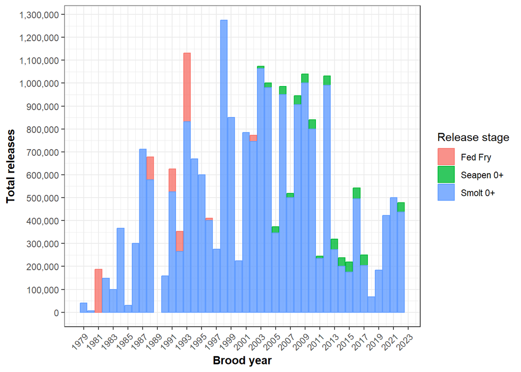

Figure 1.1: Chinook releases from 4 Mile Hatchery. Data from SEP.

### 1.1.1 Release size and timing

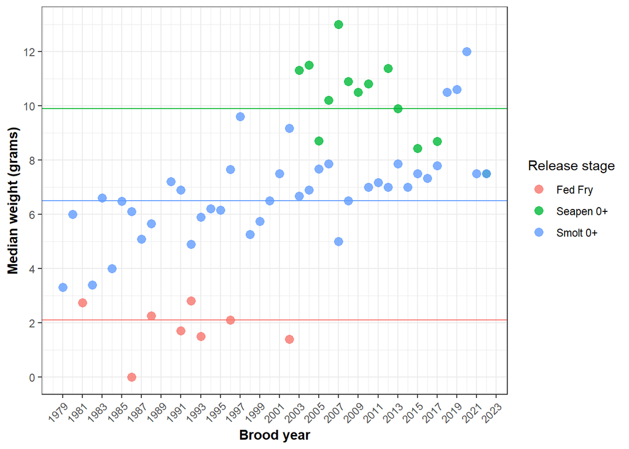

Figure 1.2: Size at release of 4 Mile Hatchery chinook. Data from SEP.

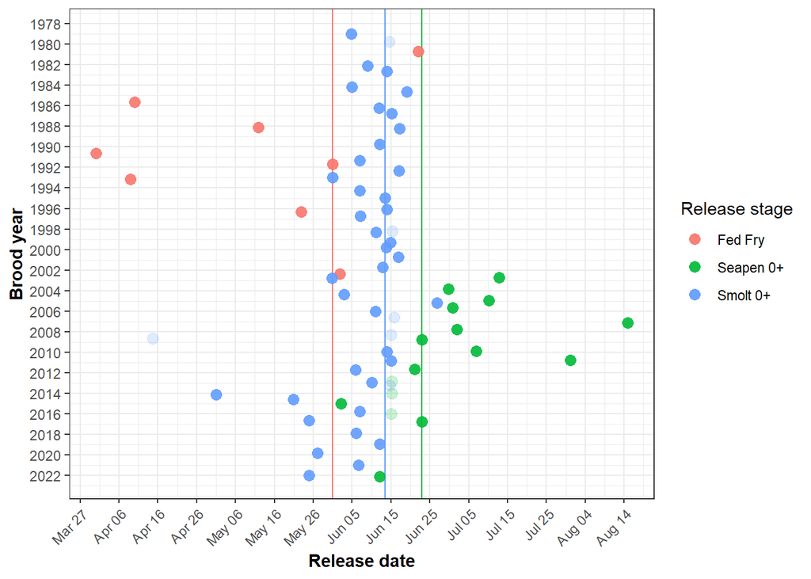

Figure 1.3: Median release date of 4 Mile Hatchery Chinook. Paler points indicate cases where release date was estimated. Data from SEP.

## 1.2 Hatchery marking

Marking of hatchery releases (and sampling of adults) has been spotty over time. Below is a brief summary of the marking/tagging rates and methods used over time at 4 Mile.

### 1.2.1 Otolith, CWT, and adipose clip

#### 1.2.1.1 Marking/tagging by brood year

Table 1.1: San Juan chinook otolith thermal marking (‘TM’), CWTing, and adipose clipping over time.

| BROOD YEAR | TM release # | TM Reference specimen mark status | # TM reference specimens | TM Quality (%): NA | TM Quality (%): Unknown | TM Quality (%): Good | TM Quality (%): Acceptable | TM Quality (%): Poor | SEP release | % CWT | %AD-only | BY mark rate | % unmarked/untagged | PBT | TM issues/comments |
| --- | --- | --- | --- | --- | --- | --- | --- | --- | --- | --- | --- | --- | --- | --- | --- |
| 1979 | NA | NA | NA | NA | NA | NA | NA | NA | 39555 | 0.989 | 0.005 | 0.994 | 0.006 | NA | NA |
| 1980 | NA | NA | NA | NA | NA | NA | NA | NA | 5560 | 0.000 | 0.000 | 0.000 | 1.000 | NA | NA |
| 1981 | NA | NA | NA | NA | NA | NA | NA | NA | 187527 | 0.520 | 0.030 | 0.550 | 0.450 | NA | NA |
| 1982 | NA | NA | NA | NA | NA | NA | NA | NA | 148677 | 0.335 | 0.012 | 0.348 | 0.652 | NA | NA |
| 1983 | NA | NA | NA | NA | NA | NA | NA | NA | 99452 | 0.000 | 0.000 | 0.000 | 1.000 | NA | NA |
| 1984 | NA | NA | NA | NA | NA | NA | NA | NA | 367000 | 0.000 | 0.000 | 0.000 | 1.000 | NA | NA |
| 1985 | NA | NA | NA | NA | NA | NA | NA | NA | 29700 | 0.000 | 0.000 | 0.000 | 1.000 | NA | NA |
| 1986 | NA | NA | NA | NA | NA | NA | NA | NA | 300325 | 0.000 | 0.000 | 0.000 | 1.000 | NA | NA |
| 1987 | NA | NA | NA | NA | NA | NA | NA | NA | 711091 | 0.147 | 0.000 | 0.148 | 0.852 | NA | NA |
| 1988 | NA | NA | NA | NA | NA | NA | NA | NA | 678464 | 0.153 | 0.002 | 0.155 | 0.845 | NA | NA |
| 1990 | NA | NA | NA | NA | NA | NA | NA | NA | 158990 | 0.000 | 0.000 | 0.000 | 1.000 | NA | NA |
| 1991 | NA | NA | NA | NA | NA | NA | NA | NA | 625000 | 0.000 | 0.000 | 0.000 | 1.000 | NA | NA |
| 1992 | NA | NA | NA | NA | NA | NA | NA | NA | 353071 | 0.385 | 0.000 | 0.385 | 0.615 | NA | NA |
| 1993 | NA | NA | NA | NA | NA | NA | NA | NA | 1130250 | 0.045 | 0.000 | 0.045 | 0.955 | NA | NA |
| 1994 | NA | NA | NA | NA | NA | NA | NA | NA | 670000 | 0.076 | 0.000 | 0.076 | 0.924 | NA | NA |
| 1995 | NA | NA | NA | NA | NA | NA | NA | NA | 600000 | 0.000 | 0.000 | 0.000 | 1.000 | NA | NA |
| 1996 | NA | NA | NA | NA | NA | NA | NA | NA | 410000 | 0.000 | 0.000 | 0.000 | 1.000 | NA | NA |
| 1997 | NA | NA | NA | NA | NA | NA | NA | NA | 275000 | 0.000 | 0.000 | 0.000 | 1.000 | NA | NA |
| 1998 | NA | NA | NA | NA | NA | NA | NA | NA | 1275000 | 0.000 | 0.000 | 0.000 | 1.000 | NA | NA |
| 1999 | NA | NA | NA | NA | NA | NA | NA | NA | 850000 | 0.088 | 0.000 | 0.089 | 0.911 | NA | NA |
| 2000 | NA | NA | NA | NA | NA | NA | NA | NA | 224429 | 0.336 | 0.000 | 0.336 | 0.664 | NA | NA |
| 2001 | 785000 | Marked | 16 | 0.00 | 1 | 0.00 | 0.00 | 0 | 785000 | 0.096 | 0.000 | 0.096 | 0.904 | NA | READS WERE 2:1.4+2.2 FOR 16 SAMPLES |
| 2002 | 772052 | Marked | 0 | 0.00 | 1 | 0.00 | 0.00 | 0 | 772052 | 0.000 | 0.000 | 0.000 | 1.000 | NA | NO REFERENCE SAMPLES. RELEASE OF PINHEADS RESULTING FROM POOR FEED QUALITY-EWOS / NO REFERENCE SAMPLES. FED FRY RELEASE, NO REFERENCE SAMPLES. |
| 2003 | 1074172 | Marked | 0 | 0.00 | 1 | 0.00 | 0.00 | 0 | 1074172 | 0.000 | 0.000 | 0.000 | 1.000 | NA | NO SAMPLE RECEIVED |
| 2004 | 1000000 | Marked | 0 | 0.00 | 1 | 0.00 | 0.00 | 0 | 1000000 | 0.000 | 0.000 | 0.000 | 1.000 | NA | 12 HOUR THERMAL CYCLE NO SAMPLE RECEIVED |
| 2005 | 373275 | Marked | 0 | 0.00 | 1 | 0.00 | 0.00 | 0 | 373275 | 0.000 | 0.000 | 0.000 | 1.000 | NA | 12 HOUR THERMAL CYCLE NO SAMPLE RECEIVED |
| 2006 | 985155 | Marked | 0 | 0.00 | 1 | 0.00 | 0.00 | 0 | 985155 | 0.000 | 0.000 | 0.000 | 1.000 | NA | NO SAMPLE 12 HOUR THERMAL CYCLE |
| 2007 | 518510 | Marked | 0 | 0.00 | 1 | 0.00 | 0.00 | 0 | 518510 | 0.000 | 0.000 | 0.000 | 1.000 | NA | NO REFERENCE SAMPLE. THERMAL RECORDS PROVIDED BY HATCHERY |
| 2008 | 945650 | Marked | 0 | 0.00 | 1 | 0.00 | 0.00 | 0 | 945650 | 0.000 | 0.000 | 0.000 | 1.000 | NA | NO SAMPLE BUT THERMAL RECORDS(COHO POSSIBLY INCIDENTALLY MARKED) |
| 2009 | 0 | Not Marked | 0 | 1.00 | 0 | 0.00 | 0.00 | 0 | 1038800 | 0.000 | 0.000 | 0.000 | 1.000 | NA | FOUR MILE HATCHERY NO SAMPLE - MAURICE TREMBLAY NOT MARKED THIS YEAR DUE TO WATER TEMPERATURE ISSUES (SEE NOCN09115 AND NOCN09103)1,038,800 NOT THERMALLY MARKED. |
| 2010 | 840000 | Marked | 35 | 0.20 | 0 | 0.80 | 0.00 | 0 | 840000 | 0.000 | 0.000 | 0.000 | 1.000 | NA | mark application issue: actual mark applied was not the intended mark applied |
| 2011 | 245000 | Marked | 15 | 0.07 | 0 | 0.07 | 0.87 | 0 | 245000 | 0.000 | 0.000 | 0.000 | 1.000 | NA | ok |
| 2012 | 1031800 | Marked | 10 | 0.00 | 0 | 1.00 | 0.00 | 0 | 1031800 | 0.000 | 0.000 | 0.000 | 1.000 | NA | mark application issue: actual mark applied was not the intended mark applied |
| 2013 | 319000 | Marked | 10 | 0.00 | 0 | 1.00 | 0.00 | 0 | 319000 | 0.141 | 0.000 | 0.141 | 0.859 | NA | mark application issue: actual mark applied was not the intended mark applied |
| 2014 | NA | Not Marked | 17 | 1.00 | 0 | 0.00 | 0.00 | 0 | 237435 | 0.158 | 0.000 | 0.158 | 0.842 | NA | mark application issue: actual mark applied was not the intended mark applied |
| 2015 | NA | Not Marked | 10 | 1.00 | 0 | 0.00 | 0.00 | 0 | 219352 | 0.203 | 0.001 | 0.204 | 0.796 | NA | mark application issue: actual mark applied was not the intended mark applied |
| 2016 | 0 | Not Marked | 10 | 1.00 | 0 | 0.00 | 0.00 | 0 | 542856 | 0.089 | 0.000 | 0.089 | 0.911 | NA | mark application issue: actual mark applied was not the intended mark applied |
| 2017 | 249899 | Not Marked | 10 | 1.00 | 0 | 0.00 | 0.00 | 0 | 249899 | 0.180 | 0.002 | 0.182 | 0.818 | Incomplete | mark application issue: actual mark applied was not the intended mark applied |
| 2018 | 66794 | Marked | 10 | 0.00 | 0 | 1.00 | 0.00 | 0 | 66794 | 0.000 | 0.000 | 0.000 | 1.000 | NA | ok |
| 2019 | 184597 | Marked | 10 | 0.00 | 0 | 0.90 | 0.10 | 0 | 184597 | 0.000 | 0.000 | 0.000 | 1.000 | Full | mark application issue: actual mark applied was not the intended mark applied |
| 2020 | 422512 | Not Marked | 10 | 1.00 | 0 | 0.00 | 0.00 | 0 | 422512 | 0.000 | 0.000 | 0.000 | 1.000 | Full | mark application issue: actual mark applied was not the intended mark applied |
| 2021 | 500039 | Marked | 9 | 0.00 | 0 | 0.00 | 0.00 | 1 | 500039 | 0.075 | 0.012 | 0.086 | 0.914 | Full | ok |
| 2022 | NA | NA | 50 | 1.00 | 0 | 0.00 | 0.00 | 0 | 478224 | 0.174 | 0.000 | 0.174 | 0.826 | Full | mark application issue: actual mark applied was not the intended mark applied |

### 1.2.2 Parent-based tagging (PBT)

PBT is relatively new for San Juan Chinook, beginning in 2017 but only reliable since 2019. From Eric Rondeau, MGL:

> We’ve received what I believe to be nearly-complete brood in 2018-2021. I would say it is reliable from 2019-2021, as 2018 was missing sex ID information which complicates the process. We received ~1/3 of the brood in 2017, so I would anticipate a limited ability to PBT there as well, but not enough to reliably utilize… **I would suggest thought that 2019 is the first brood year I would recommend starting from, so for 2022 age 3.** We could probably go back to 2018 (age 4 for 2022) too if we can identify the records on sex of the samples submitted, or we can possibly run genetic sex ID marker (but hatchery records are always preferred).

Note that he says it is possible to have GSI=100% certainty, and can’t definitively be prescribed to PBT-alone. Regarding assumed PBT-origin chinook from 2015-2017 recreational catch:

> **I think it is very unlikely that those are genuinely PBT assignments.** I would suspect in this case the age was made by some other method, and that the GSI result was ~100% - it is possible the algorithm is interpreting any 100% assignment as a PBT, but this isn’t always the case (**you can have a 100% GSI**). If it wasn’t specifically marked PBT, but the GSI was 100%, I could see it being interpreted as a PBT but not actually a PBT. Do you have a few fish/Whatman/DNA IDs you could send as an example that I could verify though? We do have individuals in our baseline from San Juan from 2014 and 2015, but these are specifically marked “not brood” and no sexID was provided – these shouldn’t yield PBT IDs.

After showing example data from a few fish exported from the CREST Biodata query:

> **I would suspect in this case that all the “100s” you are looking at are from GSI. This seems slightly more common in the San Juan assignments than I’ve seen elsewhere**, but they do pop up. Usually but not always tied to related individuals in the baseline (eg. a brother or uncle, etc.) where the genetic profile is very similar to something we have, thus making the assignment probability quite high. There are a few other reasons, but they start to get more technical, I would suspect relatedness to individuals from the 2014/2015 non-brood reference collections is most likely. **I unfortunately don’t think you’ll be able to do the hatchery/natural in San Juan until roughly this year based on PBT alone, it will likely require an additional mark to complement the GSI.** Moving ahead, we’ll be able to do so confidently (with ages), but with brood only going back to ~19, there will be limited resolution based solely on PBT until now.

## 1.3 PNI

The recently-accepted WCVI Chinook Straying paper (CSAS) used only otolith thermal marks to assess PNI and straying across WCVI Chinook. The following summary of results was provided for San Juan.

Table 1.2: Proportion of hatchery-origin chinook in spawners (pHOS) and resulting Proportion of Natural Influence (PNI) for San Juan Chinook. Data from Jacob Weil, DFO.

| RecipientRiver | Year | pHOS | marked | tot.sampled | strays | PNI.tot | PNI.local |
| --- | --- | --- | --- | --- | --- | --- | --- |
| San Juan R | 2004 | 0.71 | 10 | 14 | 0 | 0.29 | 0.29 |
| San Juan R | 2005 | 0.64 | 65 | 101 | 2 | 0.36 | 0.36 |
| San Juan R | 2006 | 0.34 | 67 | 198 | 5 | 0.66 | 0.68 |
| San Juan R | 2008 | 0.01 | 1 | 84 | 1 | 0.99 | 1.00 |
| San Juan R | 2012 | 0.03 | 3 | 99 | 3 | 0.97 | 1.00 |
| San Juan R | 2014 | 0.91 | 95 | 104 | 1 | 0.09 | 0.09 |
| San Juan R | 2015 | 0.82 | 77 | 94 | 1 | NA | NA |
| San Juan R | 2017 | 0.59 | 55 | 93 | 0 | 0.41 | 0.41 |

Using recent-year data since 2012 and considering otolith thermal marks, CWTs and adipose clips, the % hatchery-origin in broodstock (pHOB) biosamples has varied considerably from >80% to <5% (see Figure 1.4). NOTE that **“natural” is only inferred by the lack of a thermal mark**, but in reality there are likely a small number of natural strays; DNA results are not available to confirm this. Most origin/composition ID is made via otolith thermal marks (see Table 1.3).

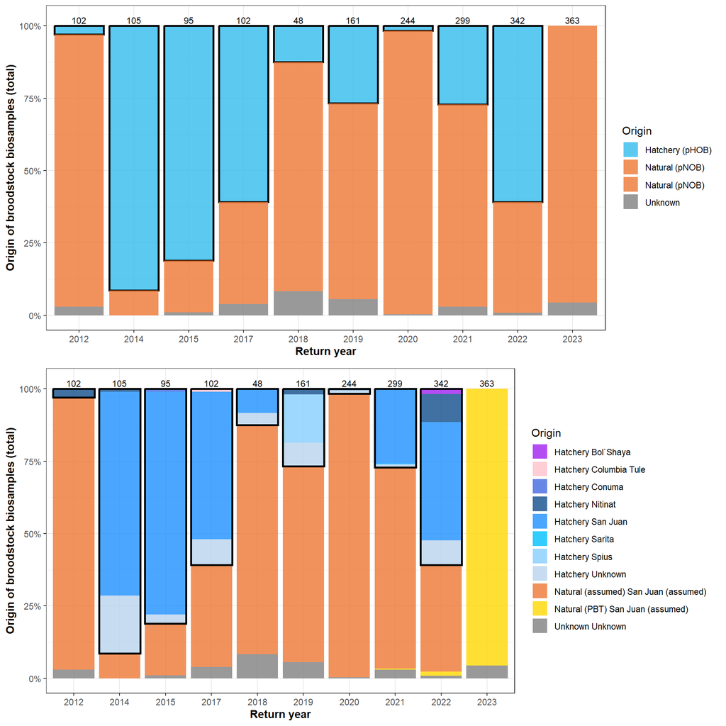

Figure 1.4: Origin of recent San Juan broodstock. Top panel shows hatchery/natural breakdown, bottom panel shows stock composition where known. Note that natural is inferred based on lack of otolith thermal mark, but no DNA available to confirm stock of origin. Numbers above bars indicate sample sizes. Data from Stock Assessment.

Table 1.3: Origin and stock ID method used to determine origin/composition of San Juan broodstock, 2012-present.

n

total

perc

2012

Broodstock

Hatchery

Otolith - Issue with BY-hatchcode read/application, identified to facility or assumed stock based on facility (least certain ID)

1

102

0.01

2012

Broodstock

Hatchery

Otolith - To stock (certain)

2

102

0.02

2012

Broodstock

Natural (assumed)

Otolith (no mark)

96

102

0.94

2012

Broodstock

Unknown

NA

3

102

0.03

2014

Broodstock

Hatchery

Otolith - To stock (certain)

75

105

0.71

2014

Broodstock

Hatchery

NA

21

105

0.20

2014

Broodstock

Natural (assumed)

Otolith (no mark)

9

105

0.09

2014

FSC

Hatchery

Otolith - Issue with BY-hatchcode read/application, identified to facility or assumed stock based on facility (least certain ID)

1

26

0.04

2014

FSC

Hatchery

Otolith - To stock (certain)

19

26

0.73

2014

FSC

Hatchery

NA

2

26

0.08

2014

FSC

Natural (assumed)

Otolith (no mark)

2

26

0.08

2014

FSC

Unknown

NA

2

26

0.08

2015

Escapement

Hatchery

Otolith - To stock (certain)

74

95

0.78

2015

Escapement

Hatchery

NA

3

95

0.03

2015

Escapement

Natural (assumed)

Otolith (no mark)

17

95

0.18

2015

Escapement

Unknown

NA

1

95

0.01

2017

Escapement

Hatchery

CWT

5

102

0.05

2017

Escapement

Hatchery

Otolith - To stock (certain)

48

102

0.47

2017

Escapement

Hatchery

NA

9

102

0.09

2017

Escapement

Natural (assumed)

Otolith (no mark)

36

102

0.35

2017

Escapement

Unknown

NA

4

102

0.04

2018

Escapement

Hatchery

Otolith - To stock (certain)

4

48

0.08

2018

Escapement

Hatchery

NA

2

48

0.04

2018

Escapement

Natural (assumed)

Otolith (no mark)

38

48

0.79

2018

Escapement

Unknown

NA

4

48

0.08

2019

Broodstock

Hatchery

Otolith - To stock (certain)

30

161

0.19

2019

Broodstock

Hatchery

NA

13

161

0.08

2019

Broodstock

Natural (assumed)

Otolith (no mark)

109

161

0.68

2019

Broodstock

Unknown

NA

9

161

0.06

2020

Broodstock

Hatchery

Otolith - To stock (certain)

1

244

0.00

2020

Broodstock

Hatchery

NA

3

244

0.01

2020

Broodstock

Natural (assumed)

Otolith (no mark)

239

244

0.98

2020

Broodstock

Unknown

NA

1

244

0.00

2021

Broodstock

Hatchery

CWT

14

299

0.05

2021

Broodstock

Hatchery

Otolith - To stock (certain)

13

299

0.04

2021

Broodstock

Hatchery

PBT

51

299

0.17

2021

Broodstock

Hatchery

NA

3

299

0.01

2021

Broodstock

Natural (PBT)

PBT (no match)

1

299

0.00

2021

Broodstock

Natural (assumed)

Otolith (no mark)

208

299

0.70

2021

Broodstock

Unknown

NA

9

299

0.03

2022

Broodstock

Hatchery

Otolith - Issue with BY-hatchcode read/application, identified to facility or assumed stock based on facility (least certain ID)

6

342

0.02

2022

Broodstock

Hatchery

Otolith - To stock (certain)

173

342

0.51

2022

Broodstock

Hatchery

NA

29

342

0.08

2022

Broodstock

Natural (PBT)

PBT (no match)

5

342

0.01

2022

Broodstock

Natural (assumed)

Otolith (no mark)

126

342

0.37

2022

Broodstock

Unknown

NA

3

342

0.01

2023

Escapement

Natural (PBT)

PBT (no match)

347

363

0.96

2023

Escapement

Unknown

NA

16

363

0.04